# Проект. Этап № 3

Неравновесная агрегация, фрактальные кластеры

Ощепков Дмитрий, Алади Принц, Хамдамова Айжана, Козлов Всеволод

Российский университет дружбы народов, Москва, Россия

21 марта 2025

# Информация

## Докладчики

**НФИбд-01-22:** * Ощепков Дмитрий * Хамдамова Айжана * Козлов Всеволод * Алади Принц

# Вводная часть

## Актуальность

Существуют разнообразные физические процессы, основная черта которых — неравновесная агрегация:

- образование частиц сажи
- выращивание кристаллов соли
- распространение воды в нефти

## Цель и задачи

**Цель работы**

Исследовать модель агрегации, ограниченной диффузией(DLA).

**Задачи**

- Построить модель агрегации, ограниченной диффузией
- Найти размерность, получившихся кластеров
- Построить график зависимости числа частиц в кластере от радиуса гирации

## Объект и предмет исследования

- Модель DLA, BA, CLA, CCA
- Фрактальная размерность
- График зависимости числа частиц в кластере от радиуса гирации

## Материалы и методы

- Язык программирования Julia

# Теоретическое описание задачи

## Фрактальная размерность

$$d = \lim_{\epsilon \rightarrow
0}(\dfrac{ln(N(\epsilon))}{ln(\dfrac{1}{\epsilon})})$$

*l**n*(*N*(*ϵ*)) = *D**l**n*(*R*) + *b*,

где *D* – фрактальная размерность, *N*(*ϵ*) – число частиц на расстоянии меньшем чем *R*, *R* – радиус.

## Агрегация, ограниченная диффузией

**Агрегация, ограниченная диффузией (diffusion-limited aggregation, DLA)** — первая модель агрегации, представляющая собой шумный рост, ограниченный диффузией.

# Практическая реализация

## Описание алгоритма

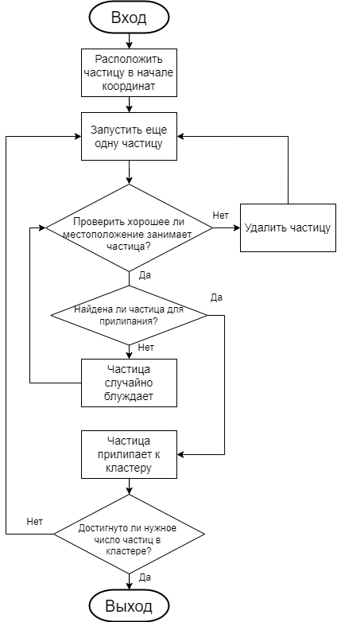

Блок-схема алгоритма модели DLA

## Случайное блуждане

Обозначим *v*<sup>*u*</sup> = (0,1) , *v*<sup>*d*</sup> = (0,−1), *v*<sup>*r*</sup> = (1,0), *v*<sup>*l*</sup> = (−1,0) - шаг на 1 вверх, вниз, влево, вправо соответственно.

{*S*<sub>*n*</sub>} – ряд, описывающий случайное блуждание, * = *u*, *d*, *r*, *l*, *n* – количество шагов

$$S_n = \sum^n_{i=1}{v_n^*},$$

$$P(v_{i+1} = v_n^*) = \dfrac{1}{4}$$

# Результаты

## DLA кластер(Diffusion-Limited Aggregation)

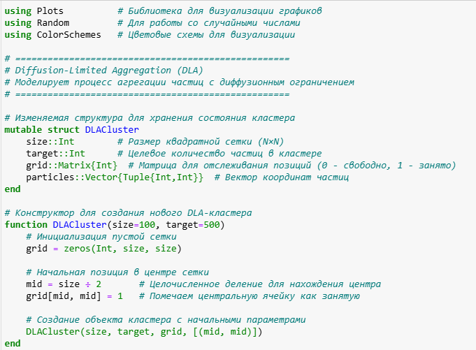

DLA кластер

## DLA кластер(Diffusion-Limited Aggregation)

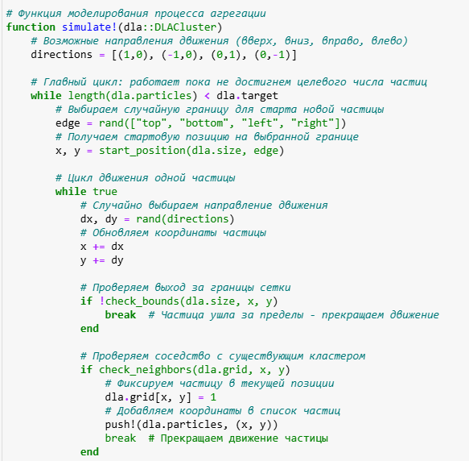

DLA кластер

## DLA кластер(Diffusion-Limited Aggregation)

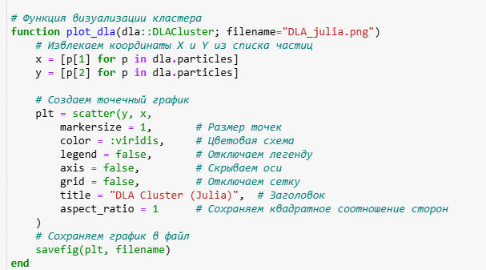

DLA кластер

## DLA кластер(Diffusion-Limited Aggregation)

[figure not shown]

DLA кластер

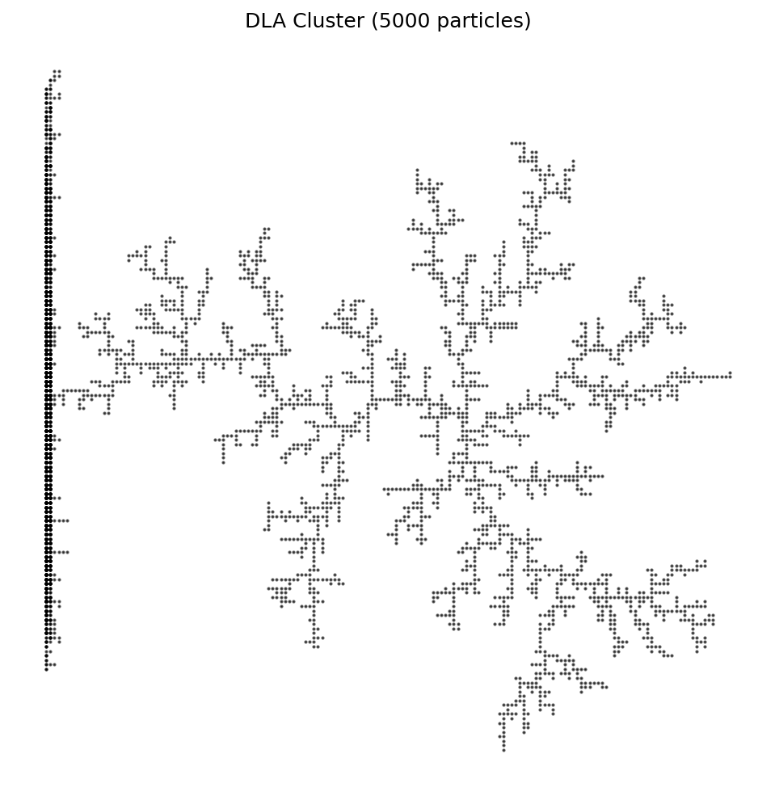

DLA кластер

## BA(Ballistic Aggregation)

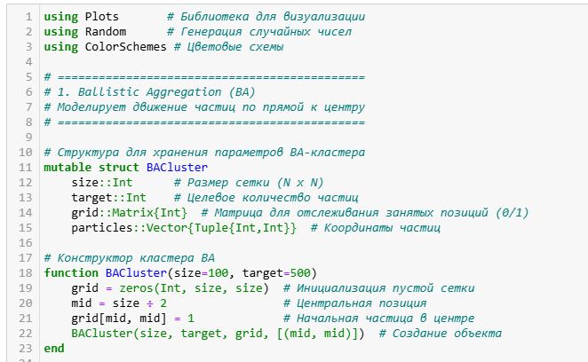

BA кластер

## BA(Ballistic Aggregation)

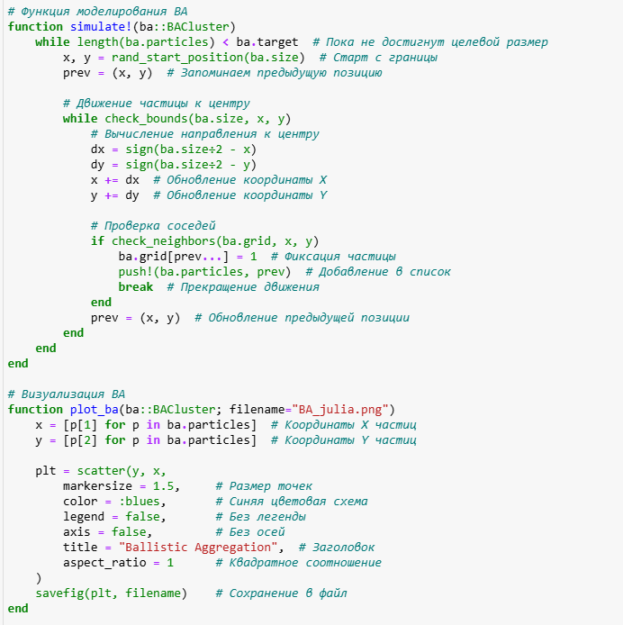

BA кластер

## BA(Ballistic Aggregation)

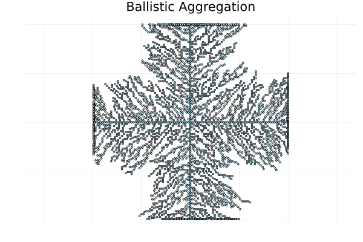

BA кластер

## CLA кластер

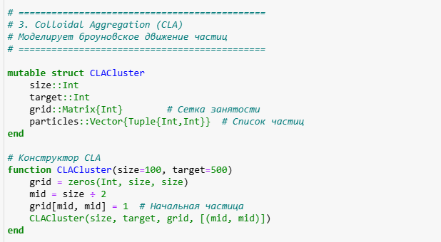

CLA кластер

## CLA кластер

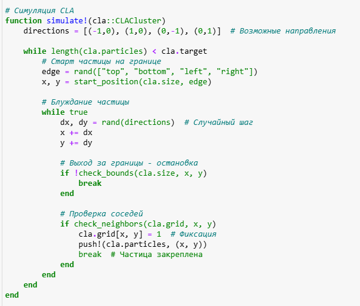

CLA кластер

## CLA кластер

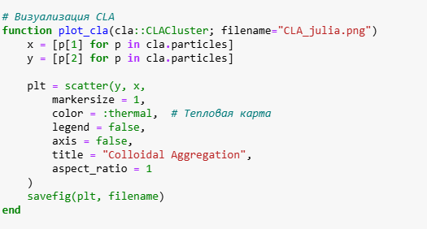

CLA кластер

[figure not shown]

CLA кластер

## CCA(Cluster-Cluster Aggregation)

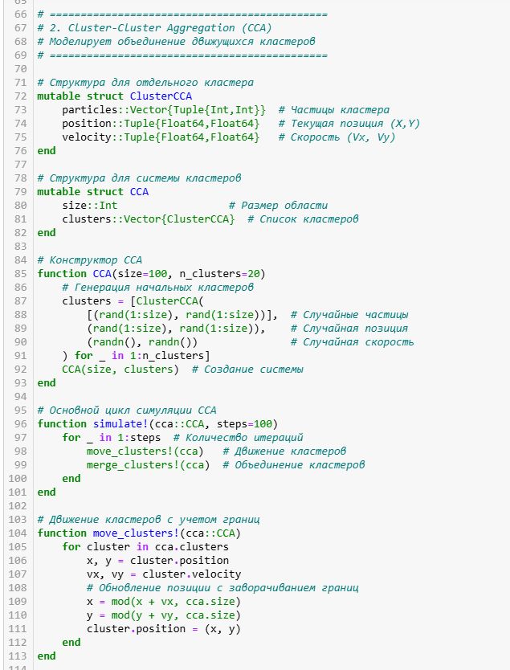

CCA кластер

## CCA(Cluster-Cluster Aggregation)

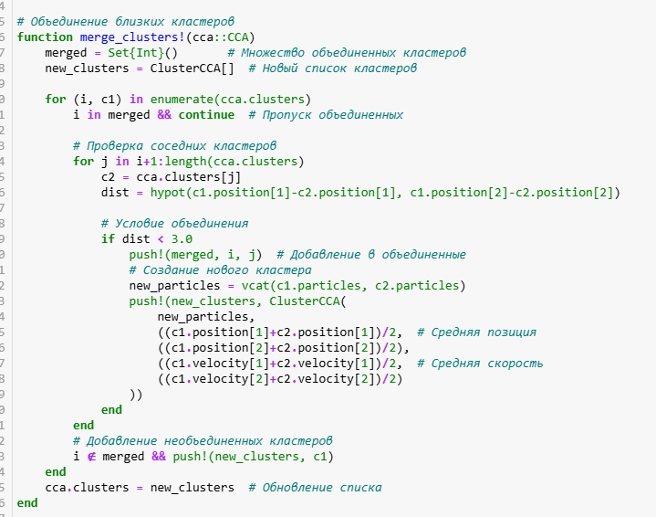

CCA кластер

## CCA(Cluster-Cluster Aggregation)

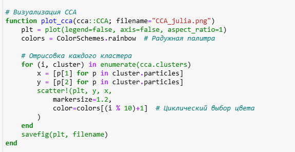

CCA кластер

## CCA(Cluster-Cluster Aggregation)

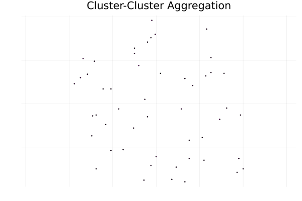

CCA кластер

## Фрактальная размерность

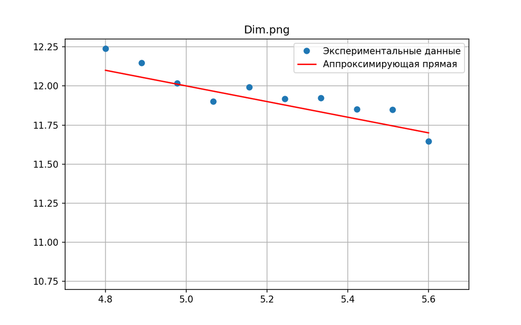

# Заключение

## Список литературы

1. Медведев Д.А. и др. Моделирование физических процессов и явлений на ПК: Учеб. пособие. Новосибирск: Новосиб. гос. ун-т, 2010. 101 с.
2. Sander L.M. Diffusion-limited aggregation: A kinetic critical phenomenon? Contemporary Physics, 2000.